# Démonstrations R - Module 08

## La question et les fichiers

Une organisation québécoise fictive prépare ses ventes mensuelles pour l’année suivante. Les ventes augmentent d’une année à l’autre et certains mois reviennent régulièrement parmi les plus élevés. Nous allons représenter ces deux mouvements, prévoir les douze mois suivants et examiner la précision obtenue.

Cette démonstration suit les activités 8.1 à 8.5 du rapport `tendance_ventes.qmd`. Pour chaque étape, lisez la question, exécutez le code, puis confrontez la sortie à son interprétation. Les corrigés repliables servent à vérifier votre réponse après votre tentative.

Décompressez le projet guidé pour compléter votre rapport, ou la démonstration complète pour retrouver cette page avec son code. Les deux projets contiennent les données, le dictionnaire et les fonctions R.

## Préparation

Ouvrez le fichier `.Rproj` du dossier décompressé. Dans la démonstration complète, ouvrez ensuite `tendance_ventes.qmd`. Les dossiers `data/` et `R/` doivent se trouver à côté de ce document. Redémarrez R avant de commencer, puis exécutez les blocs dans l’ordre ou cliquez sur Render pour refaire toute l’analyse.

Les packages `tidyverse` et `broom` doivent être installés. Au besoin, exécutez une fois `install.packages(c("tidyverse", "broom"))` dans la console. `library()` les charge dans la session courante. `source()` lit les fonctions fournies dans le projet.

```r
library(tidyverse)
library(broom)
source("R/fonctions-module08.R")

ventes <- read_csv("data/ventes_saisonnieres_quebec.csv", show_col_types = FALSE) |>
  preparer_calendrier()
stopifnot(nrow(ventes) == 72L)

apprentissage <- ventes |> slice_head(n = 60)
validation <- ventes |> slice_tail(n = 12)
futur <- calendrier_futur("2025-01-01", horizon = 12, dernier_indice = 60)
serie <- ts(apprentissage$ventes, frequency = 12, start = c(2020, 1))
```

Le fichier contient une ligne par mois, de janvier 2020 à décembre 2025. Les ventes et le budget cible sont exprimés en dollars canadiens. Les données sont entièrement simulées. La fonction `preparer_calendrier()` trie les dates, vérifie leur continuité et prépare l’indice temporel et le facteur mois.

Les objets créés ont chacun un rôle dans la comparaison.

| Objet | Contenu | Utilisation |
| --- | --- | --- |
| `apprentissage` | Les 60 mois de 2020 à 2024 | Explorer les motifs et estimer les modèles. |
| `validation` | Les douze mois de 2025, avec leurs ventes observées | Calculer les erreurs après avoir produit les prévisions. |
| `futur` | Les dates de 2025 et les prédicteurs de calendrier | Demander des prévisions émises à la fin de 2024. |
| `serie` | Les ventes d’apprentissage sous forme de série mensuelle `ts` | Lire la décomposition dans l’activité accompagnée. |

`calendrier_futur()` crée les mois de 2025 avec les indices 61 à 72. Il suffit de connaître le calendrier pour construire cet objet. L’argument `frequency = 12` de `ts()` indique douze observations par année. Cette fonction suppose une série régulière, ce que la préparation vérifie au préalable.

Pour vérifier la séparation, affichez les bornes des trois tableaux.

```r
tibble(
  ensemble = c("Apprentissage", "Validation", "Calendrier futur"),
  debut = c(min(apprentissage$date), min(validation$date), min(futur$date)),
  fin = c(max(apprentissage$date), max(validation$date), max(futur$date)),
  mois = c(nrow(apprentissage), nrow(validation), nrow(futur))
) |>
  knitr::kable(col.names = c("Ensemble", "Début", "Fin", "Nombre de mois"))
```

| Ensemble | Début | Fin | Nombre de mois |
| --- | --- | --- | --- |
| Apprentissage | 2020-01-01 | 2024-12-01 | 60 |
| Validation | 2025-01-01 | 2025-12-01 | 12 |
| Calendrier futur | 2025-01-01 | 2025-12-01 | 12 |

L’apprentissage s’arrête en décembre 2024. La validation et le calendrier futur couvrent tous deux janvier à décembre 2025. Dans l’analyse, on se place à la fin de 2024 et on prévoit les douze mois d’un seul coup. Le bloc 2025 sert ensuite à choisir parmi les candidats. Son score participe donc au choix de méthode.

## 1. Lire le temps et les motifs

### Suivre les ventes dans l’ordre des mois

Commencez par examiner les 60 mois d’apprentissage. Nous cherchons une évolution générale et des fluctuations récurrentes avant de choisir les termes de la régression.

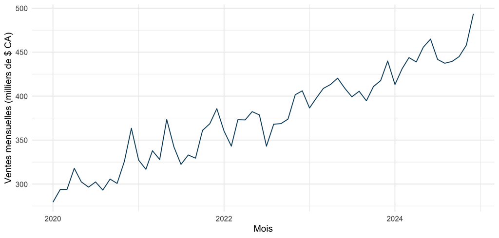

```r
ggplot(apprentissage, aes(date, ventes / 1000)) +
  geom_line(colour = "#0B4F6C") +
  labs(x = "Mois", y = "Ventes mensuelles (milliers de $ CA)") +
  theme_minimal(base_size = 12)
```

L’axe horizontal conserve l’ordre chronologique. La division par 1 000 facilite la lecture des montants sur l’axe vertical. Un point à 400 représente des ventes de 400 000 $ CA. Cette division sert à l’affichage, tandis que les modèles seront ajustés sur les ventes en dollars.

Le niveau général augmente entre 2020 et 2024, malgré des hausses et des baisses à l’intérieur des années. Une droite peut représenter une partie de cette augmentation. Pour examiner la répétition annuelle, il faut aussi comparer les mêmes mois entre années.

### Comparer janvier à janvier, puis les autres mois

Le graphique suivant superpose les cinq années d’apprentissage. Le facteur `mois` conserve l’ordre de janvier à décembre. `group = factor(annee)` demande de relier les mois d’une même année et la couleur permet de suivre cette année.

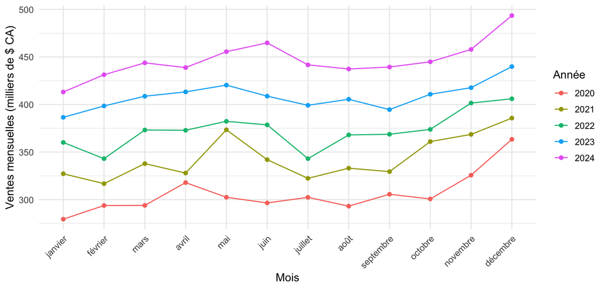

```r
ggplot(apprentissage, aes(mois, ventes / 1000,
                          group = factor(annee), colour = factor(annee))) +
  geom_line() + geom_point() +
  labs(x = "Mois", y = "Ventes mensuelles (milliers de $ CA)", colour = "Année") +
  theme_minimal(base_size = 12) +
  theme(axis.text.x = element_text(angle = 45, hjust = 1))
```

Lisez d’abord une courbe de janvier à décembre pour repérer ses mois élevés et faibles. Comparez ensuite la hauteur des courbes pour un même mois. Les profils se déplacent vers le haut au fil des années et décembre ressort régulièrement parmi les mois élevés. Cela motive un modèle qui combine une tendance et des écarts mensuels.

Ces graphiques décrivent des associations. Ils ne permettent pas d’attribuer les ventes élevées à une promotion ou à une autre intervention. Pour compléter l’activité 8.1, suivez la décomposition guidée. Elle permet de lire la part saisonnière en dollars autour d’une tendance estimée.

**AstuceCorrigé de l’activité 8.1**

Le niveau des profils monte au fil des années et décembre ressort régulièrement parmi les mois élevés. Dans la décomposition de l’apprentissage, décembre ajoute environ 24 400 $ à la tendance estimée. La moyenne centrée n’a pas de fenêtre complète aux extrémités. Une répétition en décembre ne permet pas d’attribuer la hausse à une promotion ou au calendrier lui-même.

## 2. Ajuster tendance et mois

### Distinguer le temps écoulé et le mois du calendrier

L’indice temporel augmente d’une unité à chaque nouvelle ligne. Le facteur mois revient à janvier après décembre. Vérifiez ces deux mouvements à la fin de 2020 et au début de 2021.

```r
apprentissage |>
  select(date, indice_temps, mois) |>
  slice(c(1, 2, 12, 13, 60)) |>
  knitr::kable(col.names = c("Date", "Indice temporel", "Mois"))
```

| Date | Indice temporel | Mois |
| --- | --- | --- |
| 2020-01-01 | 1 | janvier |
| 2020-02-01 | 2 | février |
| 2020-12-01 | 12 | décembre |
| 2021-01-01 | 13 | janvier |
| 2024-12-01 | 60 | décembre |

Janvier 2020 a l’indice 1 et janvier 2021 l’indice 13. Ces deux observations partagent la catégorie janvier, mais douze mois les séparent. En janvier 2025, l’indice doit donc être 61. Cette distinction permet au modèle de représenter simultanément la croissance et les différences entre mois.

### Donner un rôle à chaque modèle

Nous ajustons trois candidats sur les mêmes 60 observations. Dans une formule R, la variable à gauche de `~` est la réponse à expliquer et les variables à droite sont les prédicteurs.

| Modèle | Formule | Question posée |
| --- | --- | --- |
| Tendance | `ventes ~ indice_temps` | Comment le niveau change-t-il au fil du temps? |
| Saison | `ventes ~ mois` | Quel niveau moyen retrouve-t-on pour chaque mois? |
| Calendrier | `ventes ~ indice_temps + mois` | Comment le niveau change-t-il en tenant compte du mois? |

```r
modele_tendance <- lm(ventes ~ indice_temps, data = apprentissage)
modele_saison <- lm(ventes ~ mois, data = apprentissage,
                    contrasts = list(mois = "contr.treatment"))
modele_calendrier <- lm(ventes ~ indice_temps + mois, data = apprentissage,
                        contrasts = list(mois = "contr.treatment"))
modeles <- list(Tendance = modele_tendance, Saison = modele_saison,
                Calendrier = modele_calendrier)
```

`lm()` estime les coefficients par moindres carrés. Nous conservons les trois ajustements dans une liste nommée `modeles`, qui servira à comparer leurs diagnostics et leurs prévisions. L’argument `contrasts` fixe la comparaison des mois à janvier, premier niveau du facteur. Le facteur est non ordonné, ce qui donne un coefficient pour chacun des onze autres mois.

Le modèle combiné s’écrit

$$\widehat{y}_t = \widehat{\beta}_0 + \widehat{\beta}_1 t + \widehat{\gamma}_{m(t)},
\qquad \widehat{\gamma}_{\text{janvier}} = 0.$$

On part d’une constante, on ajoute le terme de tendance, puis l’écart du mois par rapport à janvier. La pente est commune à tous les mois et les écarts saisonniers sont constants en dollars au fil des années.

### Lire les coefficients et reconstruire une prévision

`tidy()` place les coefficients dans un tableau. Nous retenons ici la constante, la pente et décembre pour apprendre à les lire.

```r
tidy(modele_calendrier) |>
  filter(term %in% c("(Intercept)", "indice_temps", "moisdécembre")) |>
  select(term, estimate, std.error) |>
  knitr::kable(digits = 0,
               col.names = c("Terme", "Coefficient estimé", "Erreur-type"),
               format.args = list(big.mark = " ", decimal.mark = ","))
```

| Terme | Coefficient estimé | Erreur-type |
| --- | --- | --- |
| (Intercept) | 281 179 | 4 590 |
| indice_temps | 2 884 | 72 |
| moisdécembre | 32 705 | 6 026 |

La pente vaut environ 2 884 $ CA par mois à mois du calendrier égal. Entre deux janviers successifs, les indices diffèrent de 12. La différence prévue est donc d’environ 12 fois 2 884 $, soit 34 600 $ CA.

Le coefficient de décembre vaut environ 32 705 $ CA. Selon le modèle, c’est l’écart décembre-janvier à indice temporel égal. Cette comparaison est construite par la forme du modèle, puisque deux mois différents ne se produisent pas à la même date. Elle ne mesure pas un effet causal du mois. L’erreur-type décrit l’incertitude d’estimation du coefficient sous les hypothèses du modèle.

Pour janvier 2025, l’écart mensuel est nul et l’indice vaut 61. Reconstituez la prévision avec la constante et la pente.

```r
coefficients <- coef(modele_calendrier)
prevision_janvier <- coefficients["(Intercept)"] +
  61 * coefficients["indice_temps"]
round(unname(prevision_janvier))
```

```
[1] 457130
```

On obtient environ 457 130 $ CA. La constante, autour de 281 179 $, correspond au niveau de janvier pour un indice hypothétique de zéro. L’indice zéro précède l’apprentissage. Cette constante aide à écrire la droite, alors que la prévision utilise ici l’indice 61.

**AstuceCorrigé de l’activité 8.2**

Janvier 2020 et janvier 2021 ont le même mois de référence et des indices 1 et 13. La pente d’environ 2 884 $ par mois représente environ 34 600 $ entre deux janviers successifs. Le contraste de décembre ajoute environ 32 705 $ par rapport à janvier à indice égal. Le modèle suppose le même écart décembre-janvier à toutes les années.

## 3. Examiner les résidus

### Relier une vente à sa valeur ajustée

Une valeur ajustée est ce que le modèle estime pour une observation utilisée à l’apprentissage. Le résidu est la différence entre la vente observée et cette valeur ajustée.

$$r_t = y_t - \widehat{y}_t.$$

`fitted()` extrait les valeurs ajustées et `residuals()` les résidus, dans le même ordre que les observations d’apprentissage.

```r
diagnostic <- apprentissage |>
  mutate(ajuste = fitted(modele_calendrier), residu = residuals(modele_calendrier))
diagnostic |>
  select(date, ventes, ajuste, residu) |>
  slice_head(n = 2) |>
  knitr::kable(digits = 0,
               col.names = c("Date", "Vente observée ($ CA)", "Valeur ajustée ($ CA)", "Résidu ($ CA)"),
               format.args = list(big.mark = " ", decimal.mark = ","))
```

| Date | Vente observée ($ CA) | Valeur ajustée ($ CA) | Résidu ($ CA) |
| --- | --- | --- | --- |
| 2020-01-01 | 279 411 | 284 064 | -4 653 |
| 2020-02-01 | 293 801 | 287 474 | 6 327 |

En janvier 2020, la vente observée est d’environ 279 411 $ et la valeur ajustée de 284 064 $. Le résidu est donc d’environ −4 653 $ CA. Le signe négatif indique que le modèle ajuste au-dessus de l’observation. En février, le résidu positif indique la situation inverse.

### Chercher une structure dans le temps et dans la dispersion

Dans le graphique temporel, suivez les signes des résidus. De longues suites au-dessus ou au-dessous de zéro peuvent signaler une évolution mal représentée. Dans le second graphique, regardez si les points s’écartent davantage de zéro lorsque la valeur ajustée augmente.

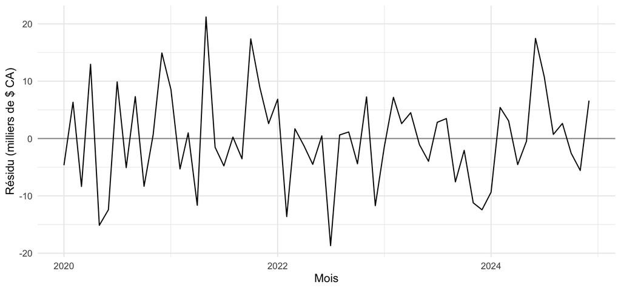

```r
ggplot(diagnostic, aes(date, residu / 1000)) +
  geom_hline(yintercept = 0, colour = "grey60") + geom_line() +
  labs(x = "Mois", y = "Résidu (milliers de $ CA)") + theme_minimal(base_size = 12)
```

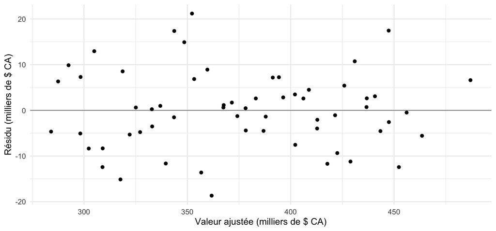

```r
ggplot(diagnostic, aes(ajuste / 1000, residu / 1000)) +
  geom_hline(yintercept = 0, colour = "grey60") + geom_point() +
  labs(x = "Valeur ajustée (milliers de $ CA)", y = "Résidu (milliers de $ CA)") +
  theme_minimal(base_size = 12)
```

Les résidus du cas guidé prennent des valeurs positives et négatives, avec des écarts allant d’environ −18 700 $ à +21 200 $. La ligne zéro représente une vente exactement ajustée. Ces graphiques aident à examiner l’adéquation de la forme et de la dispersion. L’autocorrélation sera approfondie au module 09.

### Comprendre pourquoi les moyennes mensuelles s’annulent

Nous comparons maintenant les résidus moyens de chaque mois pour les trois modèles. `imap_dfr()` parcourt la liste `modeles`. À chaque passage, `modele` contient un ajustement et `nom` son nom. Les petits tableaux produits sont ensuite réunis.

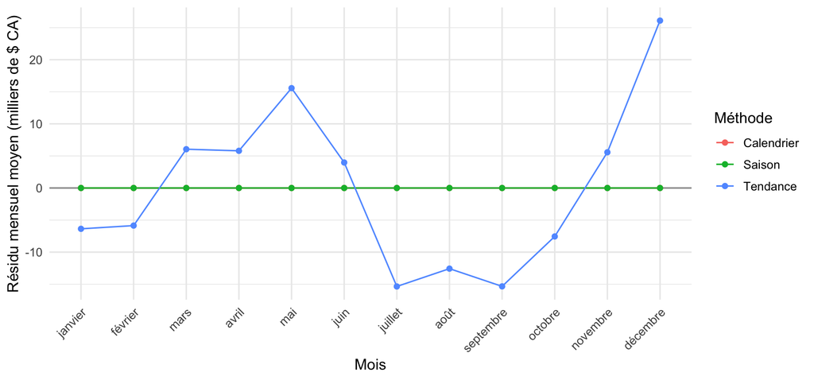

```r
residus_mensuels <- imap_dfr(modeles, function(modele, nom) {
  tibble(mois = apprentissage$mois, residu = residuals(modele), methode = nom)
}) |>
  group_by(methode, mois) |>
  summarise(residu_moyen = mean(residu), .groups = "drop")
residus_mensuels |>
  ggplot(aes(mois, residu_moyen / 1000, colour = methode, group = methode)) +
  geom_hline(yintercept = 0, colour = "grey60") + geom_line() + geom_point() +
  labs(x = "Mois", y = "Résidu mensuel moyen (milliers de $ CA)", colour = "Méthode") +
  theme_minimal(base_size = 12) +
  theme(axis.text.x = element_text(angle = 45, hjust = 1))
```

La tendance seule laisse des moyennes résiduelles qui varient selon le mois. Les modèles qui contiennent le facteur mois donnent des moyennes mensuelles presque nulles. Cette compensation vient des équations des moindres carrés avec les indicatrices mensuelles. Les courbes Saison et Calendrier se superposent donc près de zéro, même si ces modèles ne produiront pas les mêmes prévisions.

Pour juger leur utilité prédictive, il faut examiner les erreurs sur les mois qui suivent l’apprentissage. La compensation des résidus sur le passé ne permet pas de conclure que le motif mensuel restera stable.

**AstuceCorrigé de l’activité 8.3**

Les résidus du modèle combiné vont d’environ −18 700 $ à +21 200 $. Le graphique temporel permet de chercher des suites d’écarts de même signe. Le graphique selon les valeurs ajustées permet de chercher une dispersion qui change avec le niveau. Dans les modèles qui contiennent le mois, les résidus de chaque mois se compensent par construction sur l’apprentissage. Pour juger les prévisions, il faut passer à 2025.

## 4. Comparer les prévisions

### Prévoir avec le calendrier disponible à l’origine

Les trois modèles sont estimés sur 2020 à 2024. Pour chacun, `predict(modele, newdata = futur)` applique les coefficients au calendrier de 2025. Les ventes observées en 2025 sont ajoutées au tableau pour calculer les erreurs. Elles ne font pas partie des prédicteurs fournis à `predict()`.

Le quatrième candidat est le naïf saisonnier. `tail(apprentissage$ventes, 12)` extrait les ventes de janvier à décembre 2024 et les reprend, dans le même ordre, pour prévoir les mois correspondants de 2025.

```r
previsions <- imap_dfr(modeles, function(modele, nom) {
  tibble(date = futur$date, observe = validation$ventes, methode = nom,
         prevision = as.numeric(predict(modele, newdata = futur)))
}) |>
  bind_rows(tibble(date = futur$date, observe = validation$ventes,
                   methode = "Saisonnier_naif", prevision = tail(apprentissage$ventes, 12)))

previsions |>
  filter(date == as.Date("2025-01-01")) |>
  select(methode, observe, prevision) |>
  knitr::kable(digits = 0,
               col.names = c("Méthode", "Vente de janvier observée ($ CA)", "Prévision de janvier ($ CA)"),
               format.args = list(big.mark = " ", decimal.mark = ","))
```

| Méthode | Vente de janvier observée ($ CA) | Prévision de janvier ($ CA) |
| --- | --- | --- |
| Tendance | 440 906 | 464 304 |
| Saison | 440 906 | 353 290 |
| Calendrier | 440 906 | 457 130 |
| Saisonnier_naif | 440 906 | 413 161 |

Chaque ligne du tableau concerne janvier 2025. L’observation est identique pour les quatre méthodes. La prévision Calendrier, autour de 457 130 $, correspond au calcul fait avec la constante et la pente. Le tableau complet `previsions` contient 48 lignes, soit quatre méthodes pour douze mois.

### Lire les trois mesures dans leurs unités

On calcule chaque erreur par observation moins prévision. Une erreur négative indique une surestimation des ventes. `mesures08()` applique les trois formules ci-dessous aux douze erreurs de chaque méthode.

| Mesure | Calcul | Lecture |
| --- | --- | --- |
| ME | Moyenne des erreurs signées | Indique le sens moyen des écarts. Les signes peuvent se compenser. |
| MAE | Moyenne des valeurs absolues des erreurs | Donne la taille moyenne des erreurs en dollars. |
| RMSE | Racine de la moyenne des erreurs au carré | Donne plus de poids aux grandes erreurs, en dollars également. |

```r
scores <- previsions |>
  group_by(methode) |>
  group_modify(~ mesures08(.x$observe, .x$prevision)) |>
  ungroup() |>
  arrange(MAE)
scores |>
  knitr::kable(digits = 0,
               col.names = c("Méthode", "ME ($ CA)", "MAE ($ CA)", "RMSE ($ CA)"),
               format.args = list(big.mark = " ", decimal.mark = ","))
```

| Méthode | ME ($ CA) | MAE ($ CA) | RMSE ($ CA) |
| --- | --- | --- | --- |
| Calendrier | -3 538 | 9 891 | 11 280 |
| Tendance | -4 347 | 17 064 | 20 292 |
| Saisonnier_naif | 29 067 | 29 067 | 30 170 |
| Saison | 100 302 | 100 302 | 100 872 |

`group_by(methode)` sépare les quatre candidats pour le calcul. Dans `group_modify()`, `.x` désigne les douze lignes de la méthode courante. `arrange(MAE)` classe ensuite les méthodes de la plus petite à la plus grande erreur absolue moyenne.

Le modèle Calendrier a ici la plus faible MAE, autour de 9 891 $ CA, avec une RMSE d’environ 11 280 $ CA. Sa ME, autour de −3 538 $, indique une surestimation moyenne sur ces douze mois. Le naïf saisonnier a une MAE d’environ 29 067 $. Le modèle Saison sous-prévoit fortement la dernière année, parce qu’il reprend un profil mensuel moyen sans représenter la croissance.

Le classement porte sur les quatre candidats, la même origine et les douze mêmes cibles. Puisque ce bloc sert à choisir, il faudra d’autres observations pour évaluer indépendamment la méthode retenue.

### Relier le tableau aux trajectoires

La courbe noire représente les ventes observées. Les courbes colorées représentent les prévisions. Suivez les mois où une courbe reste en dessous de la courbe noire pour relier sous-prévision et erreur positive.

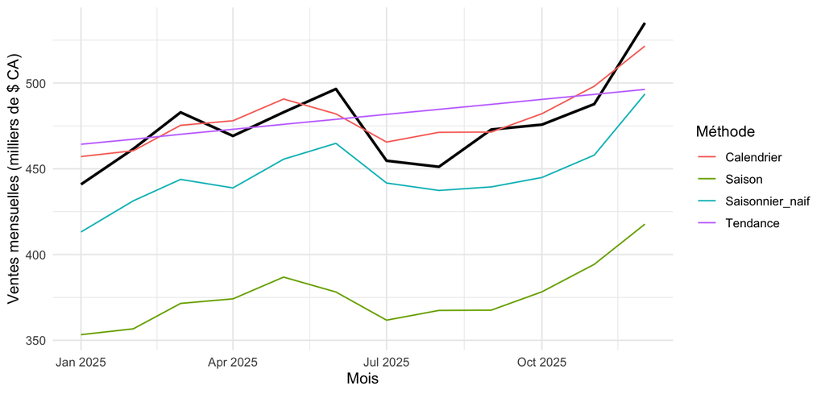

```r
ggplot() +
  geom_line(data = validation, aes(date, ventes / 1000), linewidth = 1) +
  geom_line(data = previsions, aes(date, prevision / 1000, colour = methode)) +
  labs(x = "Mois", y = "Ventes mensuelles (milliers de $ CA)", colour = "Méthode") +
  theme_minimal(base_size = 12)
```

Ce graphique permet de voir les différences que résume la MAE. La tendance seule suit la hausse générale, tandis que le modèle Calendrier ajoute un profil mensuel. La saison seule reste à un niveau trop faible pour 2025. Après cette comparaison, l’exemple accompagné de Holt-Winters et ETS montre comment d’autres méthodes représentent la saisonnalité.

**AstuceCorrigé de l’activité 8.4**

Pour janvier 2025, utilisez l’indice 61 et reprenez la vente de janvier 2024 comme référence saisonnière. Avec les douze mêmes cibles, le modèle calendrier a une MAE d’environ 9 891 $ CA, contre 29 067 $ CA pour le naïf saisonnier. La saison seule sous-prévoit la dernière année. Le modèle calendrier est le choix provisoire selon la MAE de ce bloc.

## 5. Prévoir et communiquer l’incertitude

### Distinguer deux questions pour le même mois

La prévision de janvier est une valeur centrale. Pour préparer une décision, nous calculons aussi l’incertitude autour de cette valeur. `interval = "confidence"` vise la moyenne conditionnelle des ventes pour le calendrier indiqué. `interval = "prediction"` vise une nouvelle vente mensuelle et ajoute la variabilité de cette observation.

```r
ip <- predict(modele_calendrier, newdata = futur, interval = "prediction", level = 0.95)
ic <- predict(modele_calendrier, newdata = futur, interval = "confidence", level = 0.95)
previsions_intervalle <- futur |>
  select(date, indice_temps, mois) |>
  bind_cols(as_tibble(ip)) |>
  mutate(observe = validation$ventes, budget_cible = validation$budget_cible,
         ic_inf = ic[, "lwr"], ic_sup = ic[, "upr"],
         dans_intervalle = observe >= lwr & observe <= upr)
```

Quand on demande un intervalle, `predict()` renvoie trois colonnes. `fit` est la prévision centrale, `lwr` la borne inférieure et `upr` la borne supérieure. Le tableau `previsions_intervalle` conserve ces trois colonnes de l’intervalle de prédiction et ajoute `ic_inf` et `ic_sup` pour les bornes de confiance de la moyenne.

Affichez les trois premiers mois, en arrondissant uniquement les montants présentés.

```r
previsions_intervalle |>
  select(date, fit, lwr, upr, ic_inf, ic_sup) |>
  slice_head(n = 3) |>
  knitr::kable(digits = 0,
               col.names = c("Mois", "Prévision ($ CA)", "Prédiction, borne inf.",
                             "Prédiction, borne sup.", "Moyenne, borne inf.", "Moyenne, borne sup."),
               format.args = list(big.mark = " ", decimal.mark = ","))
```

| Mois | Prévision ($ CA) | Prédiction, borne inf. | Prédiction, borne sup. | Moyenne, borne inf. | Moyenne, borne sup. |
| --- | --- | --- | --- | --- | --- |
| 2025-01-01 | 457 130 | 435 673 | 478 587 | 447 165 | 467 095 |
| 2025-02-01 | 460 540 | 439 083 | 481 998 | 450 575 | 470 506 |
| 2025-03-01 | 475 355 | 453 897 | 496 812 | 465 390 | 485 320 |

Pour janvier 2025, le modèle prévoit environ 457 130 $ CA. L’intervalle de confiance à 95 % de la moyenne va d’environ 447 165 $ à 467 095 $. L’intervalle de prédiction va d’environ 435 673 $ à 478 587 $. Les deux intervalles ont la même valeur centrale, mais le second doit aussi tenir compte de la variabilité d’une nouvelle observation.

### Lire le ruban puis vérifier les observations

Le ruban représente les intervalles de prédiction pour chaque mois. La ligne donne les prévisions centrales et les points les ventes observées ensuite en 2025.

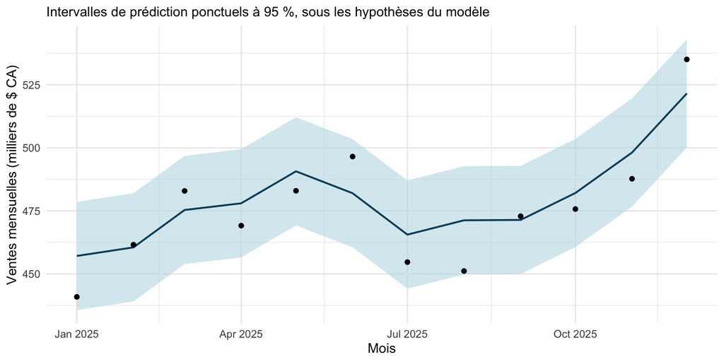

```r
ggplot(previsions_intervalle, aes(date)) +
  geom_ribbon(aes(ymin = lwr / 1000, ymax = upr / 1000), fill = "#BFDDE5", alpha = 0.6) +
  geom_line(aes(y = fit / 1000), colour = "#0B4F6C", linewidth = 0.8) +
  geom_point(aes(y = observe / 1000)) +
  labs(x = "Mois", y = "Ventes mensuelles (milliers de $ CA)",
       subtitle = "Intervalles de prédiction ponctuels à 95 %, sous les hypothèses du modèle") +
  theme_minimal(base_size = 12)
```

La variable `dans_intervalle` indique si chaque observation se trouve entre ses deux bornes. Comptons les mois concernés.

```r
previsions_intervalle |>
  summarise(mois_dans_intervalle = sum(dans_intervalle),
            ecart_moyen_au_budget = mean(fit - budget_cible)) |>
  knitr::kable(digits = 0,
               col.names = c("Mois dans leur intervalle", "Prévision moins budget, moyenne ($ CA)"),
               format.args = list(big.mark = " ", decimal.mark = ","))
```

| Mois dans leur intervalle | Prévision moins budget, moyenne ($ CA) |
| --- | --- |
| 12 | 81 483 |

Les douze observations se trouvent ici dans leurs intervalles ponctuels à 95 %. Ce petit nombre ne permet pas de conclure à une couverture de 95 % sur d’autres années. Les intervalles classiques reposent sur la forme du modèle et sur des erreurs indépendantes de variance constante, avec normalité pour les calculs exacts. Ils ne tiennent pas compte de toute l’incertitude liée au choix du modèle. Des écarts saisonniers qui changent ou des erreurs dépendantes peuvent les rendre inadéquats.

Les intervalles concernent chacun un mois. Pour obtenir une plage à 95 % sur le total annuel, il faudrait tenir compte de la dépendance entre les erreurs mensuelles. Additionner simplement les bornes ne permet pas de retrouver ce niveau pour l’année.

Le budget cible est un objectif fictif. La seconde colonne du bilan compare les prévisions centrales à cet objectif. Un écart positif indique que la prévision dépasse le budget en moyenne. Ce calcul se lit séparément des erreurs, qui comparent les prévisions aux ventes observées.

### Formuler une décision et prévoir son suivi

La recommandation rassemble le choix, deux mesures, une interprétation du calendrier et une limite. Elle précise aussi comment réexaminer le choix quand de nouvelles ventes arrivent. Une plage de ventes peut alimenter la planification budgétaire. Le risque acceptable et les décisions de stocks ou de personnel demandent des informations supplémentaires.

Pour prévoir une année suivant 2025, réajustez la méthode choisie avec les observations disponibles à cette nouvelle origine. Ses futures erreurs pourront être calculées à l’arrivée des ventes.

**AstuceCorrigé de l’activité 8.5**

En janvier 2025, l’intervalle de confiance de la moyenne va d’environ 447 165 $ à 467 095 $. L’intervalle de prédiction d’une vente va d’environ 435 673 $ à 478 587 $.

Exemple de recommandation. Retenir le calendrier pour la planification provisoire. Sur 2025, sa MAE est d’environ 9 891 $ CA et sa RMSE de 11 280 $ CA. Il représente des mois récurrents comme décembre, sous l’hypothèse d’écarts saisonniers constants. À chaque nouveau mois, consigner l’erreur. Si les écarts persistent dans le même sens, revoir l’hypothèse de tendance et réévaluer le modèle à de nouvelles origines.

## Pour consolider ou approfondir

Le cahier facultatif conserve les tendances quadratique et exponentielle, le retour à l’échelle des dollars, l’approfondissement de la décomposition, les harmoniques, le pont vers `tslm()` et les tests de stationnarité des anciens scripts. La décomposition accompagnée sert à lire un écart saisonnier dans l’activité 8.1. Les exercices commerciaux accompagnés préparent le module 09.

Les explications des fonctions de prédiction et de décomposition s’appuient sur les documentations de R Core Team, [predict.lm](https://stat.ethz.ch/R-manual/R-devel/library/stats/html/predict.lm.html) et [decompose](https://stat.ethz.ch/R-manual/R-devel/library/stats/html/decompose.html), consultées le 10 novembre 2026. Les versions de R et des packages employés sont consignées lors de la vérification des projets.

[IA Assistant IA Ouvrir le GPT du cours](https://chatgpt.com/g/g-6a0b2ec33d948191ad25b2f247b15de1-analyse-et-modelisation-des-donnees?ref=mini)